# Clase 3

## Graficos de mayor complejidad

Vamos a realizar algunos gráficos más complejos.

Queremos mostrar cuáles son las provincias con mayor cantidad de huertas escolares. Utilizamos el dataset `resumen_prov_huertas_escolares` ya que tiene las variables que nos interesa representar: `total_huertas_esc` y `provincia`. Usamos un gráfico de barras y ordenamos las provincias de mayor a menor cantidad de huertas en total.

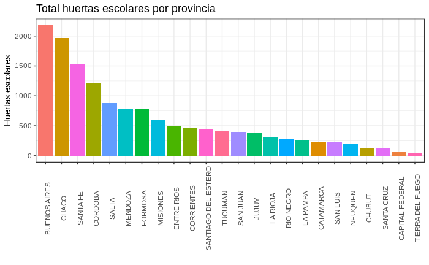

```r
ggplot(resumen_prov_huertas_escolares, aes(x=reorder(PROVINCIA, -total_huertas_esc), y=total_huertas_esc,fill=PROVINCIA)) +
  geom_bar(stat='identity') +
  theme_bw() +
  theme(legend.position = 'none', axis.text.x = element_text(angle = 90)) +
  labs(title='Total huertas escolares por provincia', y='Huertas escolares', x='')
```

Ahora queremos graficar el máximo valor de huertas escolares en un distrito por provincia y comparar ese valor con el promedio de huertas escolares en la provincia.

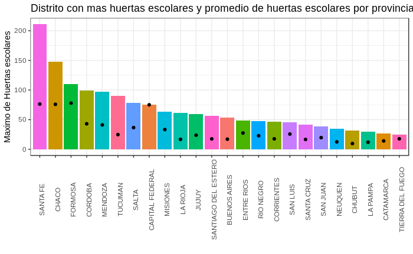

```r
ggplot(resumen_prov_huertas_escolares, aes(x=reorder(PROVINCIA, -max_huertas_esc), y=max_huertas_esc,fill=PROVINCIA)) +
  geom_bar(stat='identity') +
  geom_point(aes(y=promedio_huertas_esc)) +
  theme_bw() +
  theme(legend.position = 'none', axis.text.x = element_text(angle = 90)) +
  labs(title='Distrito con mas huertas escolares y promedio de huertas escolares por provincia', y='Maximo de Huertas escolares', x='')
```

Por último queremos mostrar la relación que existe entre cantidad total de huertas escolares, el promedio de las mismas y la cantidad de departamentos por provincia.

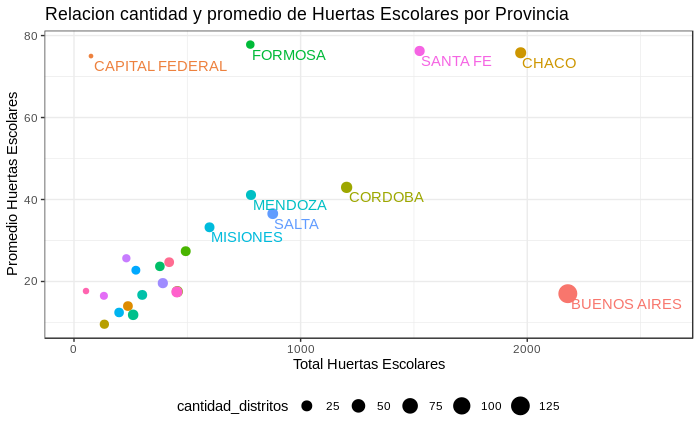

```r
ggplot(resumen_prov_huertas_escolares, aes(x=total_huertas_esc, y=promedio_huertas_esc, color=PROVINCIA)) +
  geom_point(aes(size=cantidad_distritos)) +
  geom_text(aes(label=ifelse((total_huertas_esc>500 | promedio_huertas_esc>30),as.character(PROVINCIA),'')), vjust=1.5, hjust=-0.025) +
  theme_bw() +
  scale_x_continuous(limits = c(0,2600)) +
  scale_color_discrete(guide=FALSE) +
  labs(x='Total Huertas Escolares', y='Promedio Huertas Escolares', title= 'Relacion cantidad y promedio de Huertas Escolares por Provincia') +
  theme(legend.position = 'bottom')
```